# Week 6 Tutorials: Visualising Uncertainty

161.307 Reproducible Visualisation for Statistics

Author

School of Mathematical and Computational Sciences, Massey University

Published

19 Aug 2026

## Overview

1. **Tutorial 1** - From point estimates to intervals (forest plots, error bars)
2. **Tutorial 2** - Prediction intervals and ribbons
3. **Tutorial 3** - Distributional / simulation-based uncertainty (bootstrap, quantile dotplots, violins) + bridge to networks

```r
library(ggplot2)
library(dplyr)
library(broom)
```

## Tutorial 1: From point estimates to intervals

### 1.1 Fitting a simple model

We’ll use the built-in `mtcars` dataset for simplicity (swap for a dataset relevant to you if prefer).

```r
fit <- lm(mpg ~ wt + hp + cyl, data = mtcars)
coefs <- tidy(fit, conf.int = TRUE)
coefs
```

```
# A tibble: 4 × 7
  term        estimate std.error statistic  p.value conf.low conf.high
  <chr>          <dbl>     <dbl>     <dbl>    <dbl>    <dbl>     <dbl>
1 (Intercept)  38.8       1.79       21.7  4.80e-19  35.1     42.4
2 wt           -3.17      0.741      -4.28 1.99e- 4  -4.68    -1.65
3 hp           -0.0180    0.0119     -1.52 1.40e- 1  -0.0424   0.00629
4 cyl          -0.942     0.551      -1.71 9.85e- 2  -2.07     0.187
```

### 1.2 Forest plot of coefficients

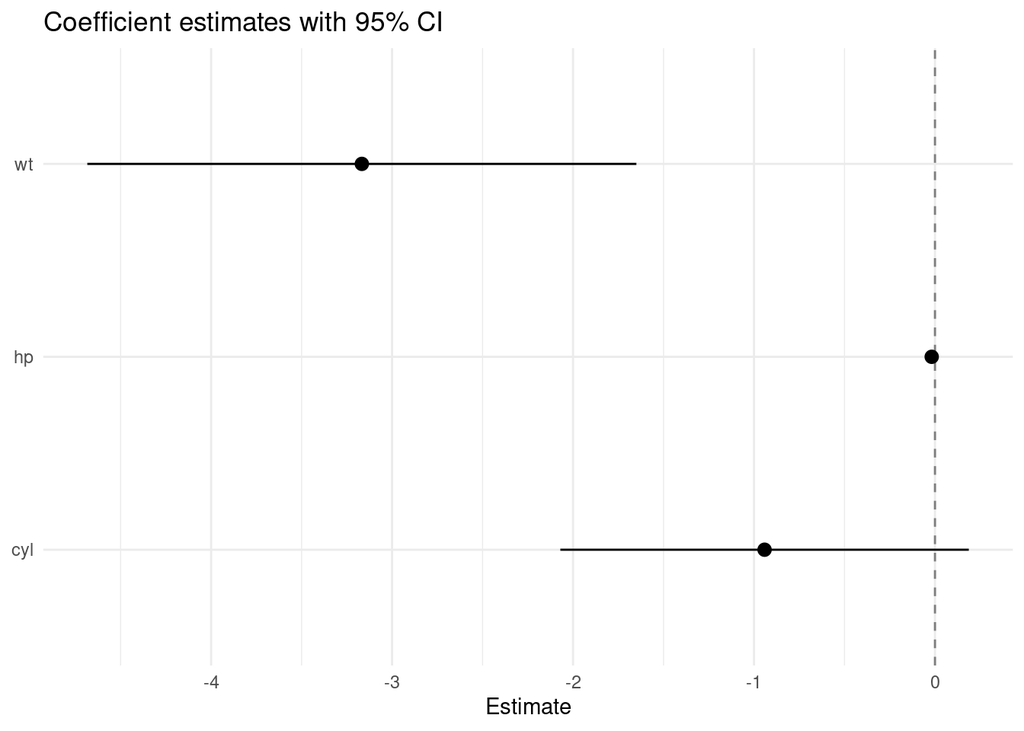

```r
coefs |>
  filter(term != "(Intercept)") |>
  ggplot(aes(x = estimate, y = term)) +
  geom_vline(xintercept = 0, linetype = "dashed", colour = "grey50") +
  geom_pointrange(aes(xmin = conf.low, xmax = conf.high)) +
  labs(title = "Coefficient estimates with 95% CI",
       x = "Estimate", y = NULL) +
  theme_minimal()
```

### 1.3 The “dynamite plot” version

**Exercise 1.1** - Reproduce the same information as a bar chart with error bars (`geom_col` + `geom_errorbar`), using `estimate` for bar height and `conf.low`/`conf.high` for the error bars. Place this next to your forest plot (e.g. with `patchwork`).

Write 2-3 sentences: which is clearer for *negative* coefficients? What does the bar chart visually imply about zero that the forest plot doesn’t?

### 1.4 Labelling intervals correctly

**Exercise 1.2** - Refit the model and extract both a 90% and a 99% CI (`conf.level` argument to `tidy()` or `confint()`). Plot both intervals for each coefficient on the same forest plot (e.g. thin line for 99%, thick line for 90%, point for the estimate). Make sure your legend/ caption makes it unambiguous which interval is which. **This is the single most common omission in uncertainty plots**.

## Tutorial 2: Prediction intervals and ribbons

### 2.1 Fitted line with confidence ribbon

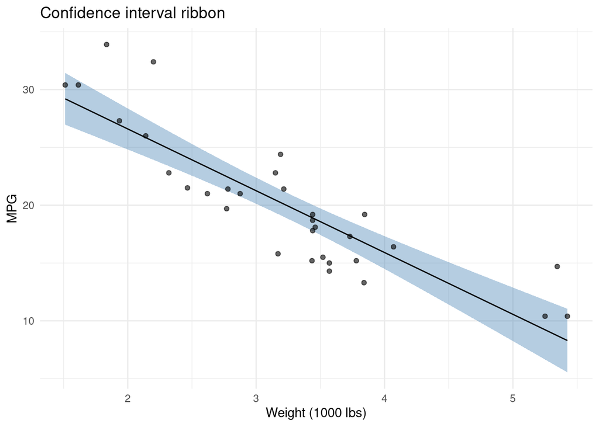

```r
fit2 <- lm(mpg ~ wt, data = mtcars)

newdata <- data.frame(wt = seq(min(mtcars$wt), max(mtcars$wt), length.out = 100))

ci <- predict(fit2, newdata = newdata, interval = "confidence")
pi <- predict(fit2, newdata = newdata, interval = "prediction")

plot_df <- newdata |>
  mutate(
    fit = ci[, "fit"],
    ci_lwr = ci[, "lwr"], ci_upr = ci[, "upr"],
    pi_lwr = pi[, "lwr"], pi_upr = pi[, "upr"]
  )

ggplot(plot_df, aes(wt)) +
  geom_ribbon(aes(ymin = ci_lwr, ymax = ci_upr), alpha = 0.4, fill = "steelblue") +
  geom_line(aes(y = fit)) +
  geom_point(data = mtcars, aes(wt, mpg), alpha = 0.6) +
  labs(title = "Confidence interval ribbon",
       x = "Weight (1000 lbs)", y = "MPG") +
  theme_minimal()
```

### 2.2 Adding the prediction interval

**Exercise 2.1** - Add the prediction interval as a second ribbon (different fill/alpha) underneath the confidence ribbon. Make sure the legend or caption clearly distinguishes the two. You can refer back to this week’s lecture 1 distinction on CI-vs-PI.

**Exercise 2.2** - Compare this ribbon plot to a Week 5 ensemble ribbon plot (your random walk summary). Both use `geom_ribbon` with similar code. In 2-3 sentences: what is the *source* of the band’s width in each case? Could a reader tell the difference just by looking at the plot, without reading axis labels/captions? What does that imply about captioning?

### 2.3 Multiple predictors

**Exercise 2.3** - Using `fit` from Tutorial (part) 1 (above; multiple predictors), produce a ribbon plot of predicted `mpg` vs `wt`, holding `hp` and `cyl` at their mean values. Note in your caption that this is a *conditional* prediction.

Discuss briefly why holding other variables at their means is a simplification.

## Tutorial 3: Distributional uncertainty

### Bootstrap refresher

```r
set.seed(123)
n_boot <- 1000

boot_coefs <- replicate(n_boot, {
  boot_sample <- mtcars[sample(nrow(mtcars), replace = TRUE), ]
  coef(lm(mpg ~ wt, data = boot_sample))["wt"]
})

boot_df <- data.frame(slope = boot_coefs)
```

**Exercise 3.1** - Before plotting, compute `mean(boot_df$slope)` and `sd(boot_df$slope)`, and compare to the SE reported by `summary(fit2)`. Are they similar? What would you expect, and why?

### Visualising the bootstrap distribution

#### Density and violin

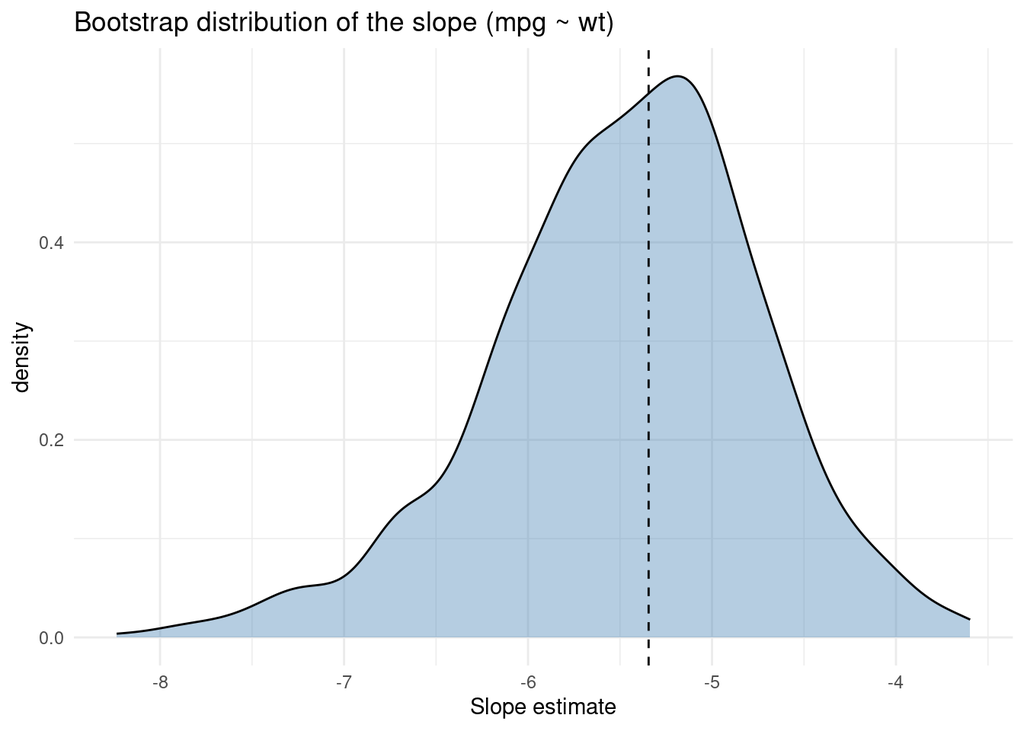

```r
ggplot(boot_df, aes(x = slope)) +
  geom_density(fill = "steelblue", alpha = 0.4) +
  geom_vline(xintercept = coef(fit2)["wt"], linetype = "dashed") +
  labs(title = "Bootstrap distribution of the slope (mpg ~ wt)",
       x = "Slope estimate") +
  theme_minimal()
```

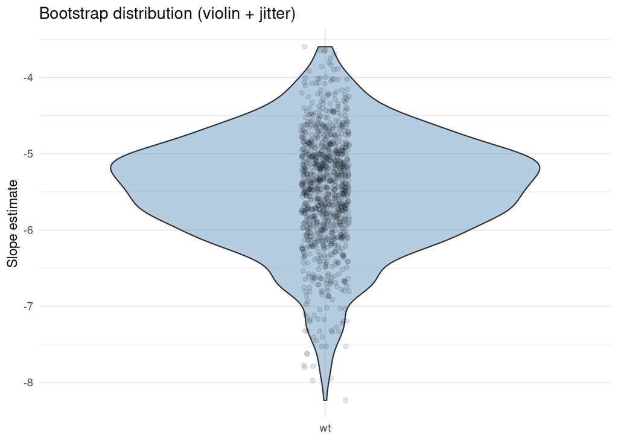

```r
ggplot(boot_df, aes(x = "wt", y = slope)) +
  geom_violin(fill = "steelblue", alpha = 0.4) +
  geom_jitter(width = 0.05, alpha = 0.1) +
  labs(title = "Bootstrap distribution (violin + jitter)",
       x = NULL, y = "Slope estimate") +
  theme_minimal()
```

#### Quantile dotplot

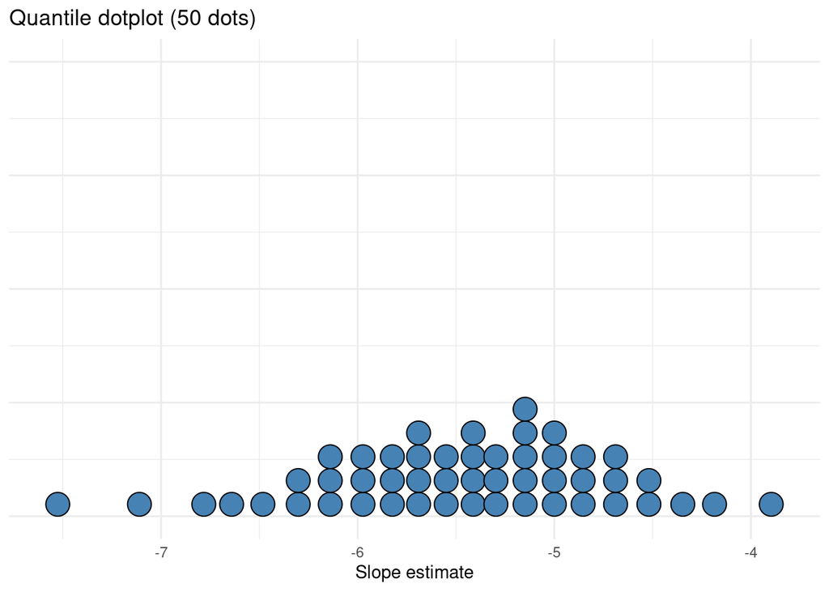

```r
# A simple quantile dotplot: discretise into 50 equally-likely outcomes
n_dots <- 50
q_vals <- quantile(boot_df$slope, probs = seq(0.5/n_dots, 1 - 0.5/n_dots, length.out = n_dots))
dot_df <- data.frame(slope = q_vals)

ggplot(dot_df, aes(x = slope)) +
  geom_dotplot(binwidth = diff(range(q_vals))/30, fill = "steelblue") +
  labs(title = "Quantile dotplot (50 dots)",
       x = "Slope estimate", y = NULL) +
  theme_minimal() +
  theme(axis.text.y = element_blank())
```

**Exercise 3.2** - Build a 1x3 comparison figure: (a) point + 95% CI error bar, (b) density/violin, (c) quantile dotplot, all showing the same bootstrap distribution of the slope. For each, write one sentence describing what additional information it conveys relative to (a).

### Reflection / written component (bring to Week 7)

In ~150 words: choose one of (b) or (c) above and describe a specific audience (e.g. policy-makers, clinicians, the general public, fellow statisticians) for whom it would communicate uncertainty *better* than a simple “estimate ± CI” statement. Justify using at least one point from this week’s readings.

### Bridge to networks (Weeks 7-8)

The bootstrap procedure above resampled *rows* of a dataset. In Week 7 we’ll meet network data, where the analogous idea is resampling *nodes or edges* of a network and recomputing a summary statistic (e.g. a centrality measure) for each resample. We will aim to produce a distribution that can be visualised with exactly the tools from this tutorial (density, violin, quantile dotplot). Keep this code as a template.